# Project 1

Andrew Sullivan

3/1/2016

**Read the data from http://www.amstat.org/publications/jse/datasets/homes76.dat.txt into an R object named `HP`.**

**Remove columns 1, 7, 10, 15, 16, 17, 18, and 19 from `HP` and store the result back in `HP`.**

**Name the columns in `HP` `price`, `size`, `lot`, `bath`, `bed`, `year`, `age`, `garage`, `status`, `active`, and `elem`, respectively.**

**Use the function `datatable` from the `DT` package to display the data from `HP`. Your data display should look similar to the one below.**

```r
HP <- read.table("http://www.amstat.org/publications/jse/datasets/homes76.dat.txt",header=TRUE)
HP <- subset(HP,select=-c(1,7,10,15:19))
HP <- rename(HP,c("Y"="price",
            "X1"="size",
            "X2"="lot",
            "X3"="bath",
            "X4"="bed",
            "X5"="age",
            "X6"="garage",
            "D7"="active"))
datatable(HP)
```

|  | price | size | lot | bath | bed | year | age | garage | status | active | elem |
| --- | --- | --- | --- | --- | --- | --- | --- | --- | --- | --- | --- |
| 1 | 388 | 2.18 | 4 | 3 | 4 | 1940 | -3 | 0 | sld | 0 | edison |
| 2 | 450 | 2.054 | 5 | 3 | 4 | 1957 | -1.3 | 2 | sld | 0 | edison |
| 3 | 386 | 2.112 | 5 | 2 | 4 | 1955 | -1.5 | 2 | sld | 0 | edison |
| 4 | 350 | 1.442 | 6 | 1 | 2 | 1956 | -1.4 | 1 | act | 1 | adams |
| 5 | 155.5 | 1.8 | 1 | 2 | 4 | 1994 | 2.4 | 1 | sld | 0 | adams |
| 6 | 220 | 1.965 | 5 | 2 | 3 | 1940 | -3 | 1 | sld | 0 | adams |
| 7 | 239.5 | 1.8 | 4 | 1.1 | 4 | 1958 | -1.2 | 1 | act | 1 | parker |
| 8 | 207 | 2.254 | 4 | 2 | 4 | 1961 | -0.9 | 2 | sld | 0 | parker |
| 9 | 269.9 | 1.922 | 4 | 2.1 | 4 | 1965 | -0.5 | 2 | act | 1 | parker |
| 10 | 238.8 | 1.92 | 5 | 2.1 | 3 | 1968 | -0.2 | 2 | sld | 0 | parker |

[output cut: 66 more lines]

**What are the units for `price` and `size`? Use the function `stepAIC` from the `MASS` package to create models using forward selection and backward elimination. Store the model from backward elimination in an object named `mod.be` and the model from forward selection in an object named `mod.fs.`**

`price` is in thousands of dollars, and `size` is in thousands of ft$^2$.

```r
mod.fs <- stepAIC(lm(price ~ 1, data = HP), scope = .~size + lot + bath + bed + year + age + garage + status + active + elem, direction = "forward", test = "F")
mod.be <- stepAIC(lm(price ~ size + lot + bath + bed + year + age + garage + status + active + elem, data = HP), scope = .~size + lot + bath + bed + year + age + garage + status + active + elem, direction = "backward", test = "F")
```

**Which model (`mod.be` or `mod.fs`) do you believe is better and why?**

```r
summary(mod.fs)
```

```
##
## Call:
## lm(formula = price ~ elem + garage + lot + active + size + bed,
##     data = HP)
##
## Residuals:
##    Min     1Q Median     3Q    Max
## -88.84 -28.53  -1.18  27.53 100.48
##
## Coefficients:
##             Estimate Std. Error t value Pr(>|t|)
## (Intercept)   83.162     56.637   1.468  0.14684
## elemcrest      5.285     33.662   0.157  0.87573
## elemedge       8.800     28.563   0.308  0.75900
## elemedison    84.223     29.604   2.845  0.00593 **
## elemharris    57.059     29.893   1.909  0.06071 .
## elemparker   -11.570     29.632  -0.390  0.69747
## garage        12.344      8.395   1.471  0.14624
## lot           10.191      3.540   2.879  0.00539 **
## active        31.728     12.673   2.504  0.01482 *
## size          77.478     27.573   2.810  0.00654 **
## bed          -13.163      8.564  -1.537  0.12915
## ---
## Signif. codes:  0 '***' 0.001 '**' 0.01 '*' 0.05 '.' 0.1 ' ' 1
##
## Residual standard error: 44.59 on 65 degrees of freedom
## Multiple R-squared:  0.5267, Adjusted R-squared:  0.4539
## F-statistic: 7.233 on 10 and 65 DF,  p-value: 1.484e-07
```

```r
summary(mod.be)
```

```
##
## Call:
## lm(formula = price ~ size + lot + bed + status + elem, data = HP)
##
## Residuals:
##     Min      1Q  Median      3Q     Max
## -91.369 -29.241  -0.705  24.313 113.296
##
## Coefficients:
##             Estimate Std. Error t value Pr(>|t|)
## (Intercept)  118.460     54.739   2.164  0.03414 *
## size          90.210     26.319   3.428  0.00106 **
## lot           10.754      3.480   3.091  0.00294 **
## bed          -15.786      8.018  -1.969  0.05324 .
## statuspen    -20.543     16.227  -1.266  0.21004
## statussld    -43.291     12.890  -3.359  0.00131 **
## elemcrest      1.261     33.763   0.037  0.97033
## elemedge      11.903     28.145   0.423  0.67376
## elemedison    85.616     29.470   2.905  0.00501 **
## elemharris    58.506     29.680   1.971  0.05296 .
## elemparker   -11.034     29.546  -0.373  0.71004
## ---
## Signif. codes:  0 '***' 0.001 '**' 0.01 '*' 0.05 '.' 0.1 ' ' 1
##
## Residual standard error: 44.54 on 65 degrees of freedom
## Multiple R-squared:  0.5277, Adjusted R-squared:  0.4551
## F-statistic: 7.263 on 10 and 65 DF,  p-value: 1.393e-07
```

`mod.be` seems to be a better model because it has a higher adjusted $R^2$ value and a lower standard error.

**Create a model and name it `mod1` that regresses price on all of the variables in `HP` with the exception of `status` and `year`. Produce a summary of `mod1` and graph the residuals using `residualPlots` from the `car` package. Based on your residual plots, what might you do to `mod1`? Report the adjusted $R^2$ value for `mod1`.**

```r
mod1 <- lm(price ~ . - status - year, data = HP)
summary(mod1)
```

```
##
## Call:
## lm(formula = price ~ . - status - year, data = HP)
##
## Residuals:
##     Min      1Q  Median      3Q     Max
## -87.265 -27.217  -0.222  30.125  95.583
##
## Coefficients:
##             Estimate Std. Error t value Pr(>|t|)
## (Intercept)   88.144     57.780   1.526  0.13214
## size          69.782     30.934   2.256  0.02756 *
## lot           10.750      3.667   2.932  0.00469 **
## bath           4.615     11.748   0.393  0.69575
## bed          -12.459      9.120  -1.366  0.17676
## age            1.626      3.324   0.489  0.62643
## garage        10.053      9.261   1.086  0.28182
## active        30.874     12.902   2.393  0.01971 *
## elemcrest      4.809     34.067   0.141  0.88819
## elemedge       7.466     29.050   0.257  0.79802
## elemedison    87.195     30.810   2.830  0.00624 **
## elemharris    53.786     30.629   1.756  0.08394 .
## elemparker   -11.904     30.009  -0.397  0.69296
## ---
## Signif. codes:  0 '***' 0.001 '**' 0.01 '*' 0.05 '.' 0.1 ' ' 1
##
## Residual standard error: 45.11 on 63 degrees of freedom
## Multiple R-squared:  0.5305, Adjusted R-squared:  0.4411
## F-statistic: 5.932 on 12 and 63 DF,  p-value: 8.906e-07
```

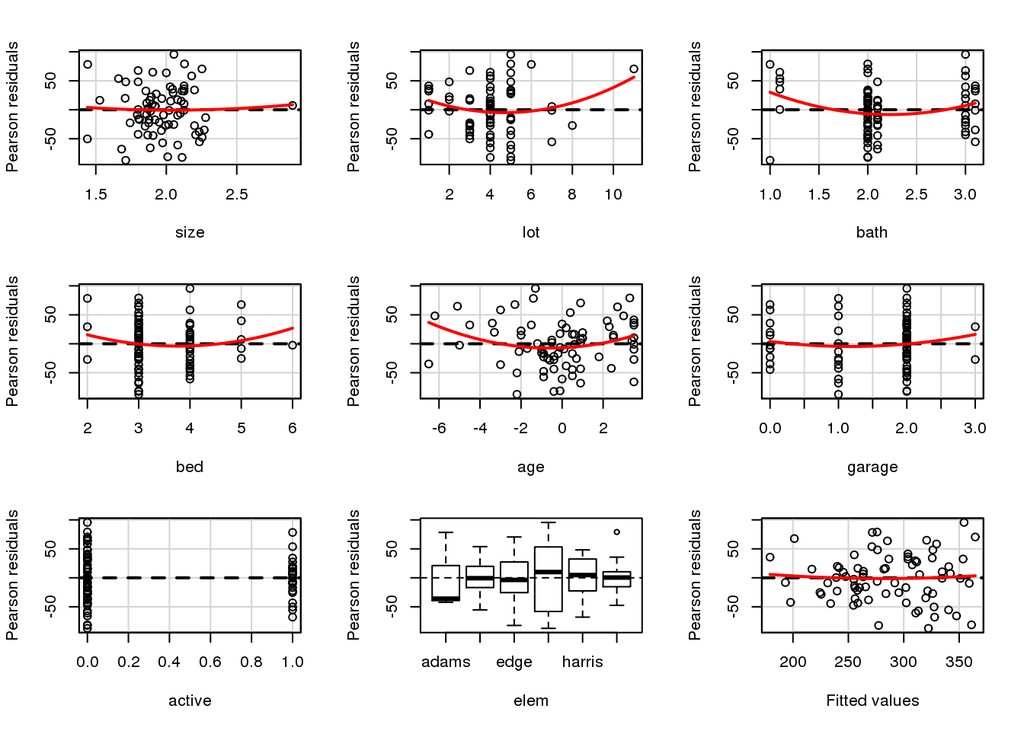

```
##            Test stat Pr(>|t|)
## size           0.303    0.763
## lot            1.979    0.052
## bath           2.376    0.021
## bed            1.011    0.316
## age            2.316    0.024
## garage         0.813    0.419
## active        -2.159    0.035
## elem              NA       NA
## Tukey test     0.333    0.739
```

```r
residualPlots(mod1)
```

Several of the residual plots are curves (non-linear), indicating that we should try introducing non-linear transformations into the model, particularly for the `lot`, `bed`, `bath`, and `age` predictors.